# Data analysis

Stéphane Le Crom, Lucie Gaspard-Boulinc, Matthieu Moreau & Gaëlle Lelandais

August 2025

Objective: To identify biologically significant target genes, you must first select the differentially expressed ones. Then, perform functional analyses to pinpoint the most biologically relevant targets.

This practical is divided in 2 sections:

1. Search for differentially expressed genes
2. Functional analyzes of the selected genes

In their article (Guida et al., 2011), the authors repeated the experiment **4 times for normoxic** condition (with O<sub>2</sub>) and **4 times for hypoxic** conditions (without O<sub>2</sub>).

# Search for differentially expressed genes - microarrays

Expressions of genes between the two conditions were compared using microarrays **(Ratio = hypoxia / normoxia)**.

You will perform this analysis for microarrays using the [limma package](http://bioinf.wehi.edu.au/limma)

## Limma library loading

```r
library(limma)
```

## Data loading of the normalized log ratio intensity value for each replicates

**Input:** A text file with four different biological replicates after normalization.

```r
dataFile <- "/shared/projects/2528_ens_master2lf_fgat/data/microarrays/dataFile_diffAnalysis.txt"
data <- as.matrix(read.table(dataFile, row.names = 1, header = T))
```

```r
# Retrieve some information from the data table
dim(data)
```

```
## [1] 5526    4
```

```r
data[1:10,1:4]
```

```
##                   logVal1      logVal2      logVal3     logVal4
## CPAR2_201050 -0.265265616 -0.130465012  0.008997103 -0.06624613
## CPAR2_101960 -0.843512598 -0.608422137 -0.103000282 -0.45358870
## CPAR2_101290  0.056414092  0.000296908 -0.068354697  0.05983511
## CPAR2_405520  0.464588136  0.509999239  0.284349940  0.44530769
## CPAR2_201590 -0.230207648 -0.176294382 -0.265324830 -0.24833664
## CPAR2_103750 -0.194992750 -0.186335163  0.191242260 -0.57185971
## CPAR2_100170 -0.132982234 -0.191465175 -0.126354218  0.00331530
## CPAR2_202790  0.973402061  0.853915233  0.808972712  0.74969076
## CPAR2_301860 -0.008917937  0.018171339 -0.021780941  0.16899955
## CPAR2_106430 -1.598703129 -1.508676852 -0.642865880 -0.87494246
```

```r
summary(data)
```

```
##     logVal1            logVal2             logVal3             logVal4
##  Min.   :-3.20789   Min.   :-2.902426   Min.   :-3.634918   Min.   :-3.854502
##  1st Qu.:-0.33699   1st Qu.:-0.318338   1st Qu.:-0.252692   1st Qu.:-0.278030
##  Median :-0.01331   Median :-0.002482   Median : 0.002798   Median :-0.009852
##  Mean   : 0.02278   Mean   : 0.025141   Mean   : 0.075240   Mean   : 0.014181
##  3rd Qu.: 0.30528   3rd Qu.: 0.309444   3rd Qu.: 0.322220   3rd Qu.: 0.282426
##  Max.   : 6.65491   Max.   : 6.422750   Max.   : 6.559013   Max.   : 6.213929
```

## Linear model estimations and calculation of the Bayesian statistics

```r
# Linear model estimation
fit <- lmFit(data)

# Bayesian statistics
limma.res <- eBayes(fit)
```

If you want to go further on understanding how linear model are working, you can look at [this practical course](https://uclouvain-cbio.github.io/WSBIM2122/sec-linmod.html).

```r
# Overview of the most differentially expressed genes
head(topTable(limma.res))
```

```
##                 logFC  AveExpr        t      P.Value    adj.P.Val        B
## CPAR2_404850 6.462651 6.462651 71.45643 3.788865e-10 2.093727e-06 13.59386
## CPAR2_503990 5.168192 5.168192 61.93992 9.047930e-10 2.499943e-06 13.02649
## CPAR2_502580 3.504953 3.504953 50.62005 3.091002e-09 4.333583e-06 12.10863
## CPAR2_807620 3.614666 3.614666 50.49767 3.136868e-09 4.333583e-06 12.09684
## CPAR2_401230 3.328905 3.328905 45.27100 6.097772e-09 5.982882e-06 11.54690
## CPAG_00607   3.396506 3.396506 43.79661 7.457963e-09 5.982882e-06 11.37366
```

```r
# Retrieve result table for all genes
allgenes.limma <- topTable(limma.res, number = nrow(data))
```

Identify the differentially expressed genes using LIMMA method.

- Try different adjusted p-value thresholds: 5%, 1%, etc..
- How many genes are induced in hypoxic condition?
- How many genes are induced in normoxic condition?

## Threshold selection

```r
logFCthreshold <- 2
adjPVthreshold <- 0.01
```

## Plot results of the differential analysis

Drawing a Volcano plot using the [EnhancedVolcano Bioconductor package](https://bioconductor.org/packages/release/bioc/html/EnhancedVolcano.html)

### EnhancedVolcano library loading

```r
library(EnhancedVolcano)
```

### Volcano plot drawing

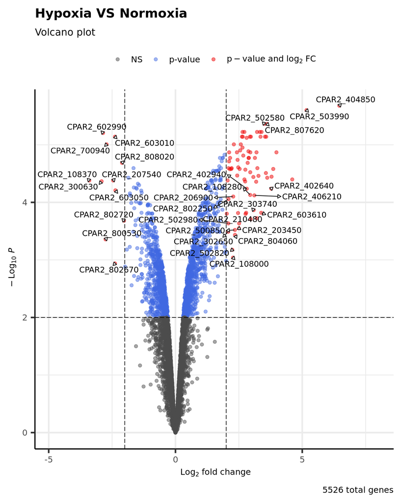

```r
EnhancedVolcano(allgenes.limma,
    lab = rownames(allgenes.limma),
    x = 'logFC',
    y = 'adj.P.Val',
    axisLabSize = 12,
    ylim = c(0,max(-log10(allgenes.limma[[5]]))),
    caption = paste0(nrow(allgenes.limma), " total genes"),
    captionLabSize = 12,
    FCcutoff = logFCthreshold,
    pCutoff = adjPVthreshold,
    title = 'Hypoxia VS Normoxia',
    subtitle = 'Volcano plot',
    pointSize = 2.0,
    labSize = 4.0,
    legendLabSize = 12,
    legendIconSize = 2.0,
    drawConnectors = TRUE)
```

**If you receive an error message preventing the volcano plot from being displayed, please enlarge the image window in your browser.**

You can use the option “selectLab” to display only the genes you are interested in on the graph passing a vector of gene names.

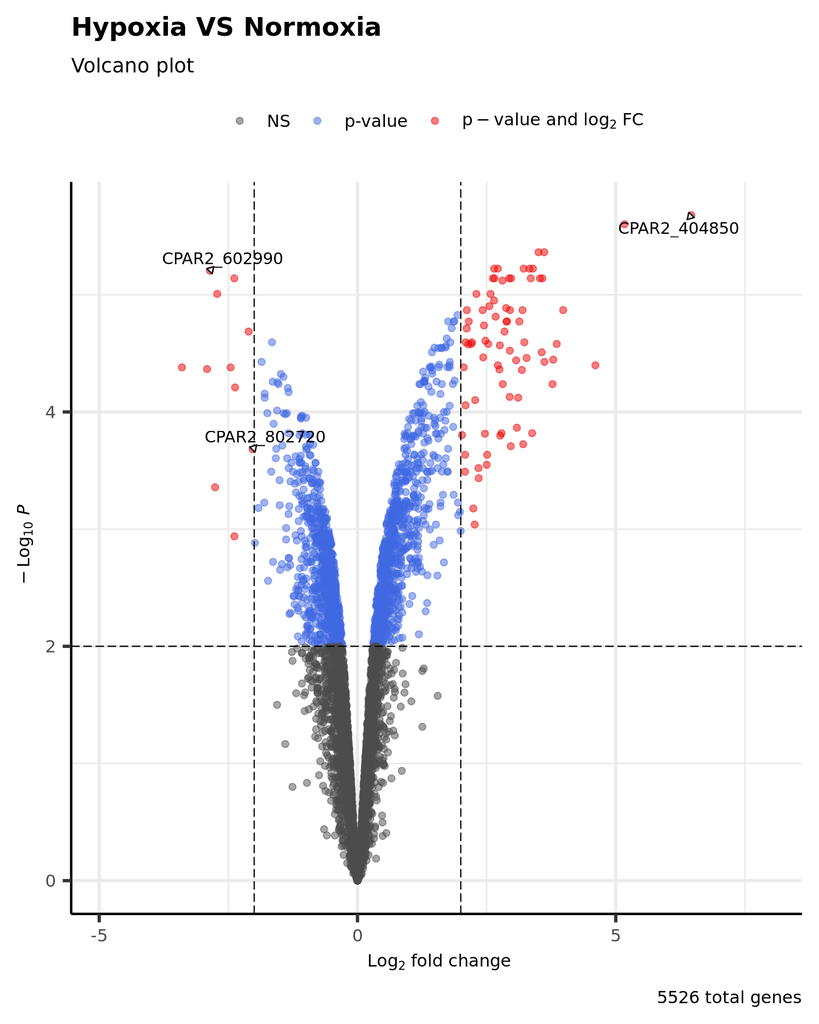

```r
EnhancedVolcano(allgenes.limma,
    lab = rownames(allgenes.limma),
    x = 'logFC',
    y = 'adj.P.Val',
    selectLab = c('CPAR2_404850','CPAR2_602990', 'CPAR2_802720'),
    axisLabSize = 12,
    ylim = c(0,max(-log10(allgenes.limma[[5]]))),
    caption = paste0(nrow(allgenes.limma), " total genes"),
    captionLabSize = 12,
    FCcutoff = logFCthreshold,
    pCutoff = adjPVthreshold,
    title = 'Hypoxia VS Normoxia',
    subtitle = 'Volcano plot',
    pointSize = 2.0,
    labSize = 4.0,
    legendLabSize = 12,
    legendIconSize = 2.0,
    drawConnectors = TRUE)
```

## Selection of differentially expressed genes (using previous thresholds)

```r
# Filter differentially expressed genes based on previous thresholds
siggenes.limma <- allgenes.limma[allgenes.limma[,5] < adjPVthreshold & abs(allgenes.limma[,1]) > logFCthreshold,]

paste(dim(siggenes.limma[siggenes.limma[,1] > 0,])[1], "genes with increased expression in Hypoxia")
```

```
## [1] "78 genes with increased expression in Hypoxia"
```

```r
paste(dim(siggenes.limma[siggenes.limma[,1] < 0,])[1], "genes with increased expression in Normoxia")
```

```
## [1] "11 genes with increased expression in Normoxia"
```

```r
# Export DE gene table into your home directory:
write.table(siggenes.limma[siggenes.limma[,1] > 0,],
            row.names = T, quote = F, sep = ";",
            file = "~/microarrays_hypoxia.csv")

write.table(siggenes.limma[siggenes.limma[,1] < 0,],
            row.names = T, quote = F, sep = ";",
            file = "~/microarrays_normoxia.csv")

print(siggenes.limma[siggenes.limma[,1] < 0,])
```

```
##                  logFC   AveExpr          t      P.Value    adj.P.Val         B
## CPAR2_602990 -2.857353 -2.857353 -40.921642 1.126926e-08 6.227391e-06 11.009444
## CPAR2_603010 -2.386064 -2.386064 -36.666590 2.195952e-08 7.238432e-06 10.396967
## CPAR2_700940 -2.716475 -2.716475 -33.338684 3.912918e-08 9.828540e-06  9.845186
## CPAR2_808020 -2.107592 -2.107592 -26.385586 1.614952e-07 2.059145e-05  8.421440
## CPAR2_108370 -3.399933 -3.399933 -21.054322 6.312015e-07 4.166148e-05  6.981216
## CPAR2_207540 -2.456284 -2.456284 -21.027727 6.360268e-07 4.166148e-05  6.973018
## CPAR2_300630 -2.913243 -2.913243 -20.849107 6.695692e-07 4.302371e-05  6.917658
## CPAR2_603050 -2.369657 -2.369657 -18.816323 1.241135e-06 6.178842e-05  6.248014
## CPAR2_802720 -2.030915 -2.030915 -13.789453 7.945638e-06 2.080929e-04  4.191489
## CPAR2_800530 -2.756817 -2.756817 -11.269853 2.610170e-05 4.397499e-04  2.852306
## CPAR2_802670 -2.383530 -2.383530  -8.602067 1.243087e-04 1.152567e-03  1.082295
```

If you want to learn more about p-values and statistical significance, [you can read this article](https://www.ncbi.nlm.nih.gov/pmc/articles/PMC6532382/)

# Search for differentially expressed genes - RNAseq

The results obtained for all experiments are combined in the file “count_data_diffAnalysis.txt”. This file will be used to search for differentially expressed genes using the DESeq2 R package [(Love et al. 2014)](https://genomebiology.biomedcentral.com/articles/10.1186/s13059-014-0550-8).

The [DESeq2 package](http://www.bioconductor.org/packages/release/bioc/html/DESeq2.html) provides methods to test for differential expression by use of the negative binonial distribution and a shrinkage estimator for the distribution’s variance.

## Library loading

```r
library(DESeq2)

library(dplyr)
library(reshape2)
library(ggplot2)

#Set ggplot theme as classic
theme_set(theme_classic())
```

## Load the raw count matrix

```r
countData <- read.table("/shared/projects/2528_ens_master2lf_fgat/data/rnaseq/count_data_diffAnalysis_no0counts.txt", row.names = 1, header = TRUE)
```

## Load metadata of the experiment (design matrix)

The **design** matrix store the information about the biological condition associated to each samples:

- N = Normoxic condition (with O<sub>2</sub>)
- H = Hypoxic condition (without O<sub>2</sub>)

```r
colData <- read.table("/shared/projects/2528_ens_master2lf_fgat/data/rnaseq/design.txt", row.names = 1, header = TRUE)
```

## Creation of the DEseq2’s specific object **DESeqDataSet**

```r
dds <- DESeqDataSetFromMatrix(countData = countData,
                             colData = colData,
                             design = ~condition)
```

## Data normalisation (same steps as yesterday)

```r
dds <- estimateSizeFactors(dds)

Raw.data <- melt(log2(counts(dds)+1))
colnames(Raw.data) <- c("ORF", "Samples","Expr.Val")
Raw.data <- data.frame(Raw.data,
                 Condition = c(substr(Raw.data$Samples[1:(4*5788)], 1, 4),
                               substr(Raw.data$Samples[(4*5788+1):nrow(Raw.data)], 1, 2)))

Norm.data <- melt(log2(counts(dds, normalized=TRUE)+1))
colnames(Norm.data) <- c("ORF", "Samples","Expr.Val")
Norm.data <- data.frame(Norm.data,
                 Condition = c(substr(Norm.data$Samples[1:(4*5788)], 1, 4),
                               substr(Norm.data$Samples[(4*5788+1):nrow(Norm.data)], 1, 2)))
```

## Variance/Dispersion estimation

```r
dds <- estimateDispersions(dds)
```

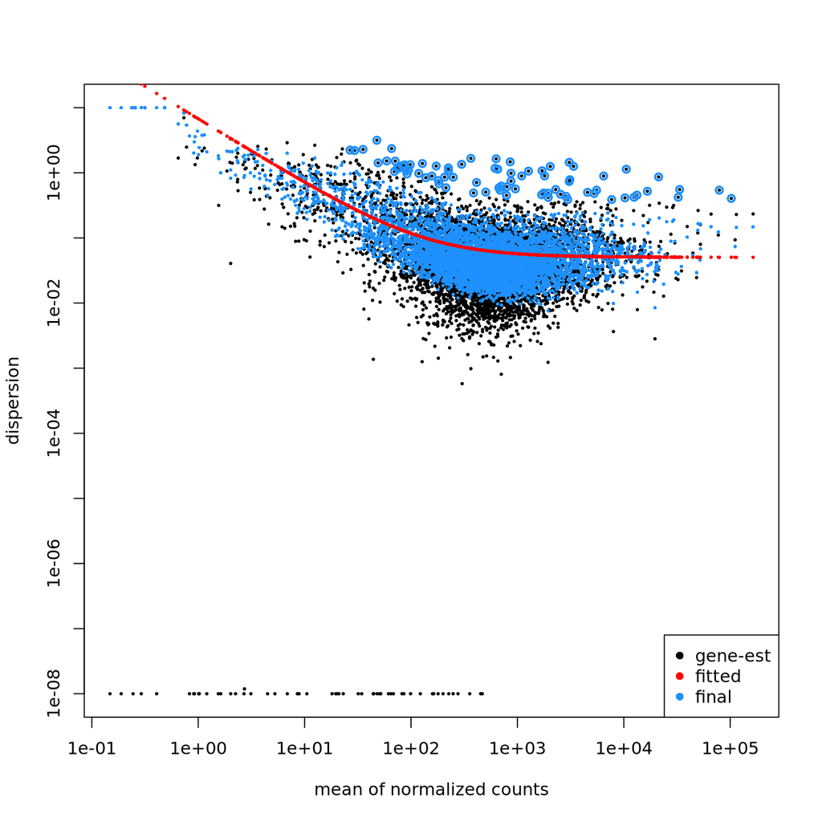

```r
plotDispEsts(dds)
```

## Negative binomial wald test implemented by DEseq2

```r
dds <- nbinomWaldTest(dds)
```

If you want to learn more on the reason why RNAseq data follow a binomial negative distribution, [you can read this blog page](https://bioramble.wordpress.com/2016/01/30/why-sequencing-data-is-modeled-as-negative-binomial/)

## Retrieve the result table

```r
res <- results(dds, contrast=c("condition","H","N"))
head(res)
```

```
## log2 fold change (MLE): condition H vs N
## Wald test p-value: condition H vs N
## DataFrame with 6 rows and 6 columns
##               baseMean log2FoldChange     lfcSE      stat     pvalue      padj
##              <numeric>      <numeric> <numeric> <numeric>  <numeric> <numeric>
## CPAR2_404750  535.3861      0.4056168  0.168628  2.405389 0.01615524 0.0405212
## CPAR2_212570  540.6451     -0.0164868  0.128962 -0.127841 0.89827441 0.9366682
## CPAR2_302130   11.2238      1.6472390  0.556416  2.960445 0.00307195 0.0103797
## CPAR2_209760  924.9407     -0.1855940  0.166547 -1.114365 0.26512276 0.3816501
## CPAR2_403260 2448.5032      0.2607853  0.229521  1.136218 0.25586548 0.3710017
## CPAR2_209040  453.7463      0.8316175  0.315945  2.632161 0.00848436 0.0242099
```

```r
# Generate a summary
summary(res)
```

```
##
## out of 5788 with nonzero total read count
## adjusted p-value < 0.1
## LFC > 0 (up)       : 1412, 24%
## LFC < 0 (down)     : 1431, 25%
## outliers [1]       : 4, 0.069%
## low counts [2]     : 0, 0%
## (mean count < 0)
## [1] see 'cooksCutoff' argument of ?results
## [2] see 'independentFiltering' argument of ?results
```

Take a look at the log2FoldChange. What is the orientation of the calculated log2FC?

```r
# Using "mcols()" you can obtain a description of the result information stored in columns
mcols(res, use.names=TRUE)
```

```
## DataFrame with 6 rows and 2 columns
##                        type            description
##                 <character>            <character>
## baseMean       intermediate mean of normalized c..
## log2FoldChange      results log2 fold change (ML..
## lfcSE               results standard error: cond..
## stat                results Wald statistic: cond..
## pvalue              results Wald test p-value: c..
## padj                results   BH adjusted p-values
```

```r
# Display the whole column description
res@elementMetadata@listData[["description"]]
```

```
## [1] "mean of normalized counts for all samples"
## [2] "log2 fold change (MLE): condition H vs N"
## [3] "standard error: condition H vs N"
## [4] "Wald statistic: condition H vs N"
## [5] "Wald test p-value: condition H vs N"
## [6] "BH adjusted p-values"
```

Convert res into data frame

```r
res <- as.data.frame(res)
```

## Diagnostic plots

### Histogram of the p values

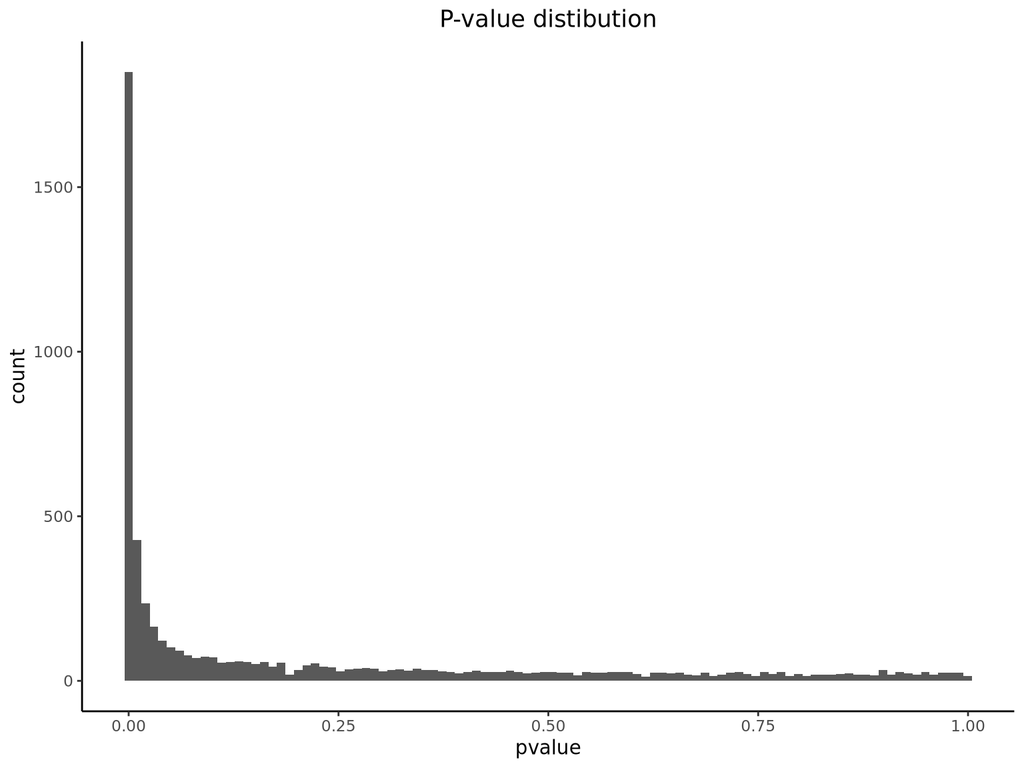

```r
ggplot(res, aes(x = pvalue)) +
  geom_histogram(bins = 100) +
  ggtitle(label = "P-value distibution") +
  theme(plot.title = element_text(hjust = 0.5))
```

### Volcan plot

We will draw a Volcano plot using the [EnhanceVolcano Bioconductor package](https://bioconductor.org/packages/release/bioc/html/EnhancedVolcano.html)

```r
# EnhanceVolcano library loading
library(EnhancedVolcano)
```

```r
# Threshold selection
logFCthreshold <- 2
adjPVthreshold <- 0.01
```

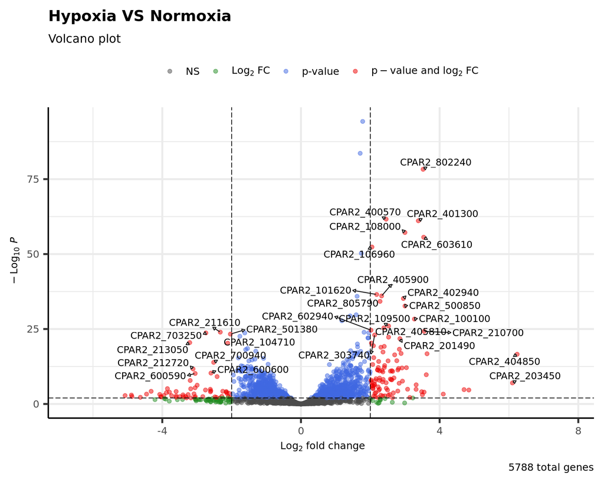

```r
# Volcano plot drawing
EnhancedVolcano(res,
    lab = rownames(res),
    x = 'log2FoldChange',
    y = 'padj',
    axisLabSize = 12,
    ylim = c(0,max(-log10(res[[6]]))),
    caption = paste0(nrow(res), " total genes"),
    captionLabSize = 12,
    FCcutoff = logFCthreshold,
    pCutoff = adjPVthreshold,
    title = 'Hypoxia VS Normoxia',
    subtitle = 'Volcano plot',
    pointSize = 2.0,
    labSize = 4.0,
    legendLabSize = 12,
    legendIconSize = 2.0,
    drawConnectors = TRUE)
```

You can use the option “selectLab” to display only the genes you are interested in on the graph passing a vector of gene names.

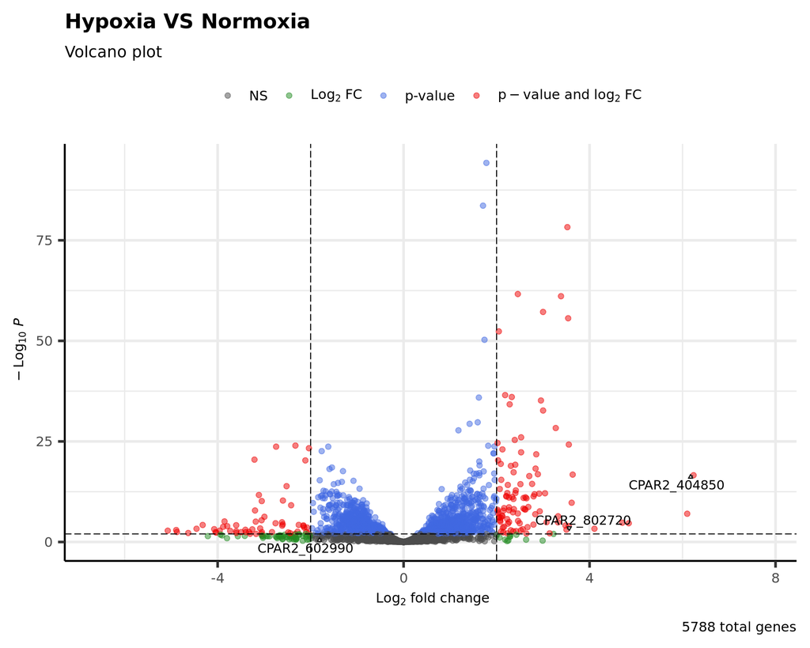

```r
# Volcano plot drawing
EnhancedVolcano(res,
    lab = rownames(res),
    x = 'log2FoldChange',
    y = 'padj',
    selectLab = c('CPAR2_404850','CPAR2_602990', 'CPAR2_802720'),
    axisLabSize = 12,
    ylim = c(0,max(-log10(res[[6]]))),
    caption = paste0(nrow(res), " total genes"),
    captionLabSize = 12,
    FCcutoff = logFCthreshold,
    pCutoff = adjPVthreshold,
    title = 'Hypoxia VS Normoxia',
    subtitle = 'Volcano plot',
    pointSize = 2.0,
    labSize = 4.0,
    legendLabSize = 12,
    legendIconSize = 2.0,
    drawConnectors = TRUE)
```

### MA plot

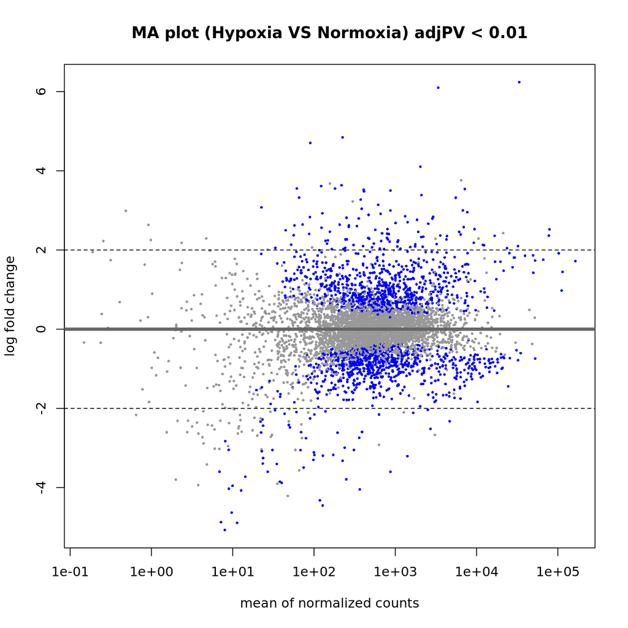

```r
plotMA(results(dds, contrast=c("condition","H","N")),
       alpha = adjPVthreshold,
       main = paste("MA plot (Hypoxia VS Normoxia) adjPV <",adjPVthreshold),
       ylim=c(min(na.omit(res[[2]])),max(na.omit(res[[2]]))))
abline(h=c(-logFCthreshold,logFCthreshold), lty=2)
```

## Export results

Genes with log2FoldChange > 2 and padj < 0.01

```r
FoldFc_pos <- res[res$log2FoldChange > logFCthreshold & res$padj < adjPVthreshold,]

paste(nrow(FoldFc_pos), "genes with increased expression in Hypoxia")
```

```
## [1] "104 genes with increased expression in Hypoxia"
```

```r
# To save the result in your home working directory
write.table(FoldFc_pos, row.names = T, quote = F, sep = ";", file = "~/rnaseq_hypoxia.csv")
```

Genes with log2FoldChange < -2 and padj < 0.01

```r
FoldFc_neg <- res[res$log2FoldChange <(-logFCthreshold) & res$padj < adjPVthreshold,]

paste(nrow(FoldFc_neg), "genes with increased expression in Normaxia")
```

```
## [1] "57 genes with increased expression in Normaxia"
```

```r
# To save the result in your home working directory
write.table(FoldFc_neg, row.names = T, quote = F, sep = ";", file = "~/rnaseq_normoxia.csv")
```

If you want to learn more about p-values and statistical significance, [you can read this article](https://www.ncbi.nlm.nih.gov/pmc/articles/PMC6532382/)

# Reproductibility

```r
#Date
format(Sys.time(), "%d %B, %Y, %H,%M")
```

```
## [1] "30 July, 2025, 14,12"
```